# Practical Machine Learning - Prediction Assignment

C. Ribeiro

10 Aug 2014

## Summary

Six male participants aged between 20-28 years, were asked to perform one set of 10 repetitions of the Unilateral Dumbbell Biceps Curl in five different ways [Velloso, E. *et al.*, 2013]. Correctly according to a specification (Class **A**) and with a set of common mistakes: throwing the elbows to the front (Class **B**), lifting the dumbbell only halfway (Class **C**), lowering the dumbbell only halfway (Class **D**) and throwing the hips to the front (Class **E**). The goal of this project is to use data from wearable sensors mounted in the user’s glove, armband, lumbar belt and dumbbell in order to build a machine learning algorithm to predict the manner in which they did exercise (outcome: *classe*) and therefore access the quality of the exercise.

The data for this project and the original paper describing the experiment are available [here](http://groupware.les.inf.puc-rio.br/har).

## Data Loading and Partition

In order to estimate the out-of-sample error, the original training data was partitioned into a training set and a validation set.

```r
library(caret, quietly = TRUE)
set.seed(1234)

pml_training <- read.csv("pml-training.csv", na.strings = c("NA", "#DIV/0!"))
dim(pml_training)
```

```
## [1] 19622   160
```

```r
inTrain <- createDataPartition(y = pml_training$classe, p = 0.7, list = FALSE)
training <- pml_training[inTrain, ]
validation <- pml_training[-inTrain, ]
dim(training)
```

```
## [1] 13737   160
```

## Preprocessing

For the purpose of this project, the variables `X`, `user_name`, `raw_timestamp_part_1`, `raw_timestamp_part_2`, `cvtd_timestamp`, `new_window` and `num_window` are not useful. They were thus removed from the training set. Some columns are predominantly constituted of NA’s. Since they could badly affect the prediction, this model includes only complete columns. *Near-zero-variance* predictors and highly correlated predictors were also identified and eliminated prior to modeling.

```r
library(corrplot)
library(dplyr, quietly = TRUE, warn.conflicts = FALSE)
# Select all columns except those from X to num_window (inclusive)
training <- select(training, -(X:num_window))
dim(training)
```

```
## [1] 13737   153
```

```r
# Select only complete columns
training <- training[, apply(training, 2, function(x) sum(is.na(x)) == 0)]
# Identify and eliminate near-zero-variance predictors.
nzv <- nearZeroVar(training, saveMetrics = TRUE)
# No near-zero-variance predictors were found after selecting complete
# columns.
summary(nzv)
```

```
##    freqRatio     percentUnique    zeroVar           nzv
##  Min.   : 1.00   Min.   : 0.04   Mode :logical   Mode :logical
##  1st Qu.: 1.06   1st Qu.: 1.96   FALSE:53        FALSE:53
##  Median : 1.10   Median : 4.61   NA's :0         NA's :0
##  Mean   : 5.97   Mean   :10.42
##  3rd Qu.: 1.15   3rd Qu.:10.69
##  Max.   :79.00   Max.   :86.28
```

```r
dim(training)
```

```
## [1] 13737    53
```

The *correlation plot* below shows that some predictors are highly correlated.

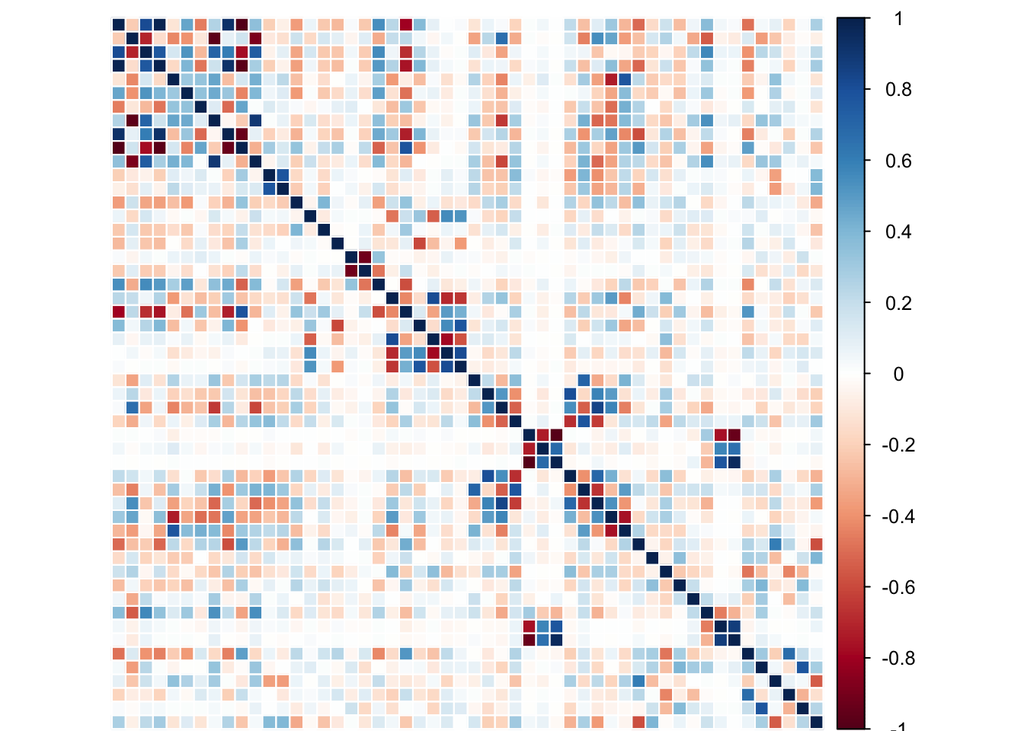

```r
trainCor <- cor(select(training, -classe))
corrplot(trainCor, method = "color", tl.pos = "n")
```

```r
# Identify and eliminate highly correlated predictors
trainHighlyCor <- findCorrelation(trainCor, cutoff = 0.9)
training <- training[, -trainHighlyCor]
dim(training)
```

```
## [1] 13737    46
```

## Random Forests

The Random Forest algorithm was chosen due to its excellent accuracy and suitability for large numbers of predictors. The classifier was tested with *10-fold cross-validation*.

```r
set.seed(1379)

modFit <- train(classe ~ ., data = training, method = "rf", trControl = trainControl(method = "cv",
    number = 10))
modFit$finalModel
```

```
##
## Call:
##  randomForest(x = x, y = y, mtry = param$mtry)
##                Type of random forest: classification
##                      Number of trees: 500
## No. of variables tried at each split: 23
##
##         OOB estimate of  error rate: 0.66%
## Confusion matrix:
##      A    B    C    D    E class.error
## A 3901    3    0    0    2    0.001280
## B   20 2632    6    0    0    0.009782
## C    0   14 2375    7    0    0.008765
## D    0    1   23 2226    2    0.011545
## E    0    0    4    8 2513    0.004752
```

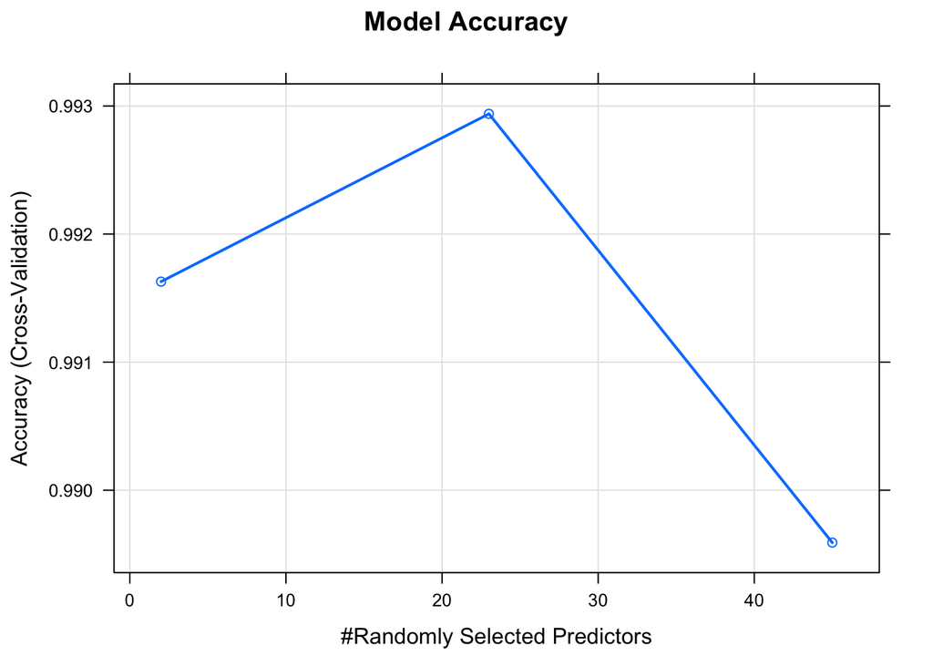

```r
# Plotting model accuracy
plot(modFit, log = "y", lwd = 2, main = "Model Accuracy")
```

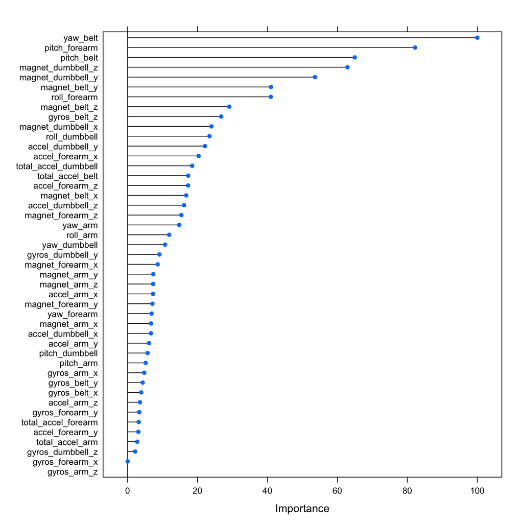

```r
# Plotting predictor importance
plot(varImp(modFit))
```

The two most important predictors are `yaw_belt` and `pitch_forearm`.

## Model Validation

```r
pred <- predict(modFit, newdata = validation)
cm <- confusionMatrix(pred, validation$classe)
cm
```

```
## Confusion Matrix and Statistics
##
##           Reference
## Prediction    A    B    C    D    E
##          A 1674    7    0    0    0
##          B    0 1129    5    1    0
##          C    0    3 1018    5    1
##          D    0    0    3  957    1
##          E    0    0    0    1 1080
##
## Overall Statistics
##
##                Accuracy : 0.995
##                  95% CI : (0.993, 0.997)
##     No Information Rate : 0.284
##     P-Value [Acc > NIR] : <2e-16
##
##                   Kappa : 0.994
##  Mcnemar's Test P-Value : NA
##
## Statistics by Class:
##
##                      Class: A Class: B Class: C Class: D Class: E
## Sensitivity             1.000    0.991    0.992    0.993    0.998
## Specificity             0.998    0.999    0.998    0.999    1.000
## Pos Pred Value          0.996    0.995    0.991    0.996    0.999
## Neg Pred Value          1.000    0.998    0.998    0.999    1.000
## Prevalence              0.284    0.194    0.174    0.164    0.184
## Detection Rate          0.284    0.192    0.173    0.163    0.184
## Detection Prevalence    0.286    0.193    0.175    0.163    0.184
## Balanced Accuracy       0.999    0.995    0.995    0.996    0.999
```

The expected *out-of-sample error* using the validation set is 1 - (prediction *Accuracy*) = 0.0046 or **0.4588 %**

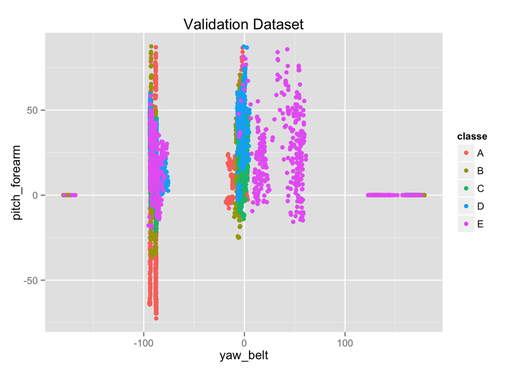

```r
validation$Predictions <- pred == validation$classe
# Classes separeted by the two most important predictors
qplot(data = validation[, -ncol(validation)], x = yaw_belt, y = pitch_forearm,
    colour = classe, main = "Validation Dataset")
```

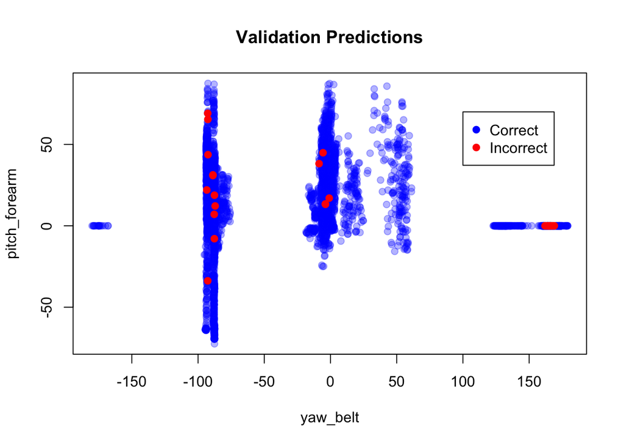

```r
## Correct/Incorrect classe predictions separeted by the two most important
## predictors
with(validation, {
    plot(yaw_belt, pitch_forearm, type = "n", main = "Validation Predictions")
    points(yaw_belt[validation$Predictions], pitch_forearm[validation$Predictions],
        col = rgb(0, 0, 255, 255 * 0.3, maxColorValue = 255), pch = 19)
    points(yaw_belt[!validation$Predictions], pitch_forearm[!validation$Predictions],
        col = "red", pch = 19)
    legend(100, 70, c("Correct", "Incorrect"), pch = 19, col = c("blue", "red"))
})
```

The plot above shows correct (blue) and incorrect (red) predictions on the validation set. The blue points have some transparency in order to emphasize the location of the incorrect predictions.

## Test Set Prediction

```r
pml_testing <- read.csv("pml-testing.csv", na.strings = c("NA", "#DIV/0!"))
test_pred <- predict(modFit, newdata = pml_testing)

test_pred
```

```
##  [1] B A B A A E D B A A B C B A E E A B B B
## Levels: A B C D E
```

```r
pml_write_files = function(x) {
    n = length(x)
    for (i in 1:n) {
        filename = paste0("problem_id_", i, ".txt")
        write.table(x[i], file = filename, quote = FALSE, row.names = FALSE,
            col.names = FALSE)
    }
}

pml_write_files(test_pred)
```

## Conclusion

The final model based on the Random Forests algorithm is highly accurate in predicting the quality of the activity (*classe*). All of the 20 test cases available in the test data used for submission were correctly predicted.

## References

Velloso, E.; Bulling, A.; Gellersen, H.; Ugulino, W.; Fuks, H. Qualitative Activity Recognition of Weight Lifting Exercises. Proceedings of 4th International Conference in Cooperation with SIGCHI (Augmented Human ’13). Stuttgart, Germany: ACM SIGCHI, 2013.